# Part II - Airline On-Time Performance Data for Summer 2022

## by Manon Mason

## Investigation Overview

Working with the Airline On-Time Performance dataset, my main goal was to study the canceled and delayed flights over the summer of 2022 and find out any patterns or relationships between variables that could help predict those delays and cancellations.

We came away with two key insights:

- Weather is one of the most disruptive problems regarding flying. Not only does it cause the most cancellations, but it also causes the longest delays.
- The timing of the flight does correlate with flight performance. Even though more flights happen in the Morning (between 6 am and noon), cancellations and delays happen more frequently and last longer in the Evening and the Afternoon.

## Dataset Overview

Airline On-Time Performance Data is a comprehensive dataset that provides valuable insights into US domestic airline performance, including carrier information, delays, and reasons for delays or cancellations. The dataset has over two millions rows and twenty nine columns.

## WEATHER

Weather is the leading cause of cancellation. However, it ranks low on delays, being second to last. We can deduce from this that most airlines decide to cancel, rather than delay, their flights when significant meteorological conditions are forecasted or currently happening.

Even though delays due to the weather happen less frequently than others; when they do occur, they cause delays of an hour on average.

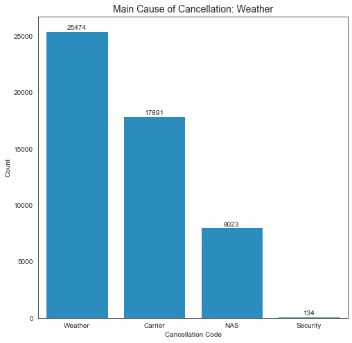

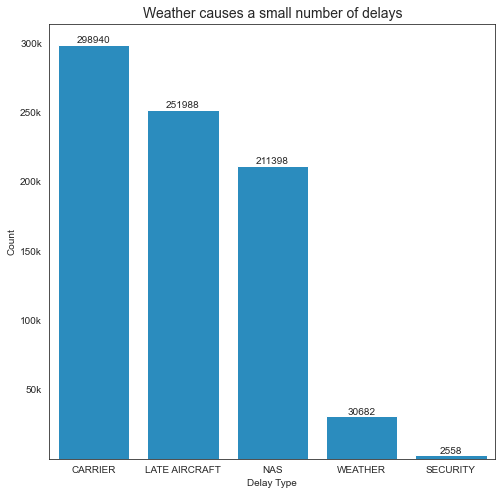

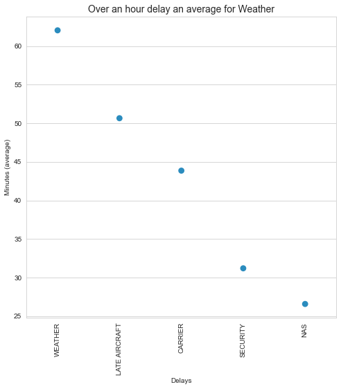

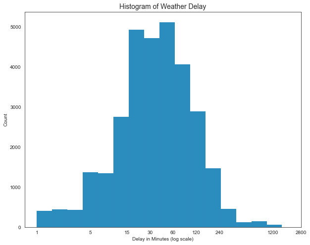

## TIME OF DAY

We have divided the day into four bins:

- Morning: 6 am-noon
- Afternoon: noon - 6 pm
- Evening: 6 pm-midnight
- Night: Midnight - 6 am

Most flights happen in the morning. However, when we look at how the cancellations and delays are spread throughout the day, we see that most occur in the evening and afternoon.

When splitting the delays by length, we can closely examine the relationship between time of day and delay.

The bins are as follows:

- Less than an hour later
- 1 to 2 hours late
- 2 to 4 hours late
- 4 to 8 hours late
- 8 to 12 hours late
- 12 to 24 hours late
- Over 24 hours late

We can see that the time of day and delay are correlated: on top of having the highest percentage of delays in the evening and afternoon, they also have longer delays compared to flights in the morning or at night.

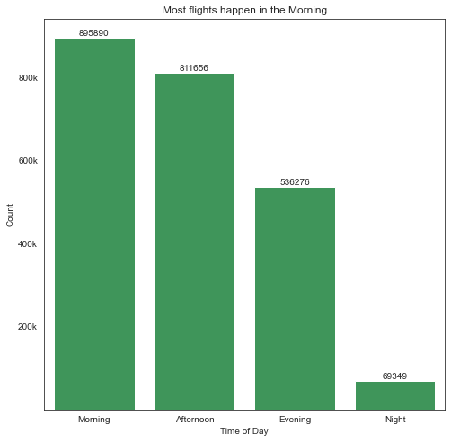

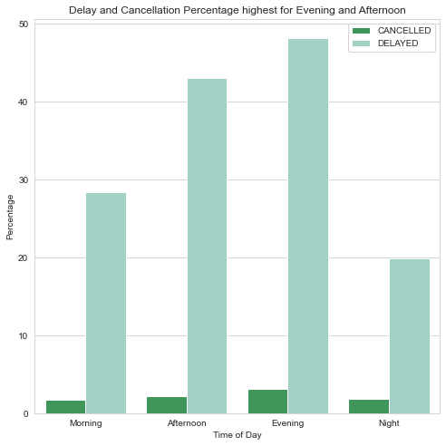

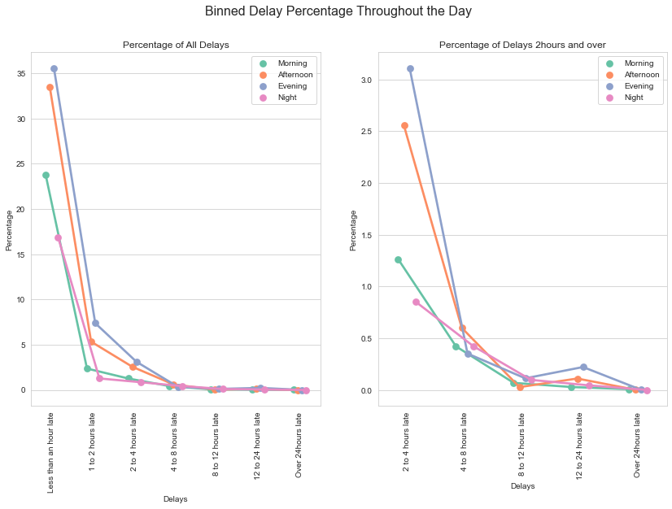